# Penalty Side Distribution Analysis

Comparing Professional, NCAA, and post-save side distributions

Author

Jake Bohane

Published

September 1, 2026

# Introduction

This report analyzes penalty-kick placement relative to the kicker’s shooting foot. The goal is divided into three equal sections: strong, center, and weak. The strong side is the same-foot side, while the weak side is the opposite-foot side. For a right-footed kicker, the right third is strong and the left third is weak; these definitions are reversed for a left-footed kicker. All directions are described from the kicker’s perspective.

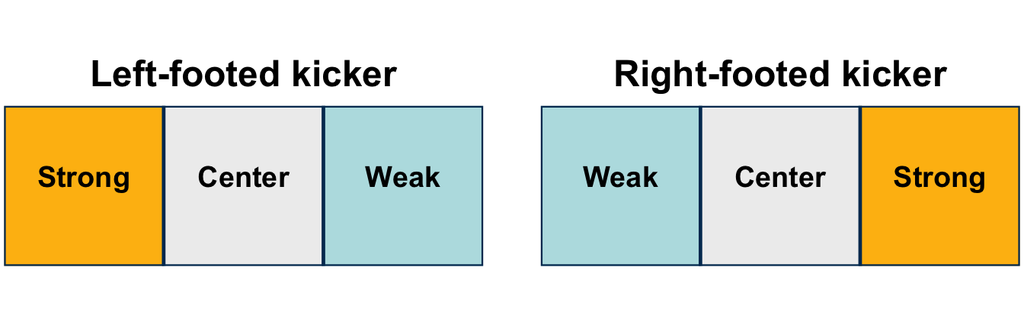

The analysis includes 1,481 professional penalties with recorded placement coordinates and 413 NCAA penalties coded from video, for a total of 1,894 valid attempts. It addresses two questions:

1. Are penalty-direction distributions consistent between the NCAA and professional samples?
2. Does a player’s direction distribution change after their previous penalty was saved?

# NCAA vs Professional Penalties

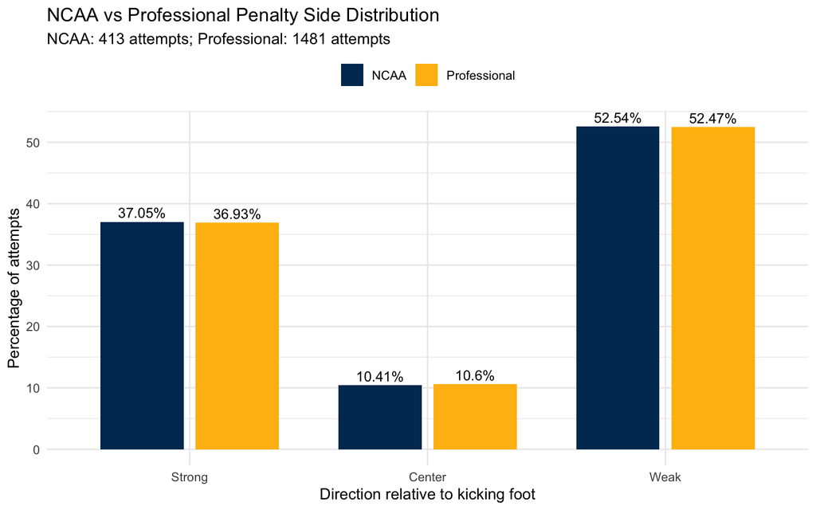

Figure 1: Penalty direction distributions in the NCAA and professional samples.

# Professional Penalty Direction Overall vs Following a Save

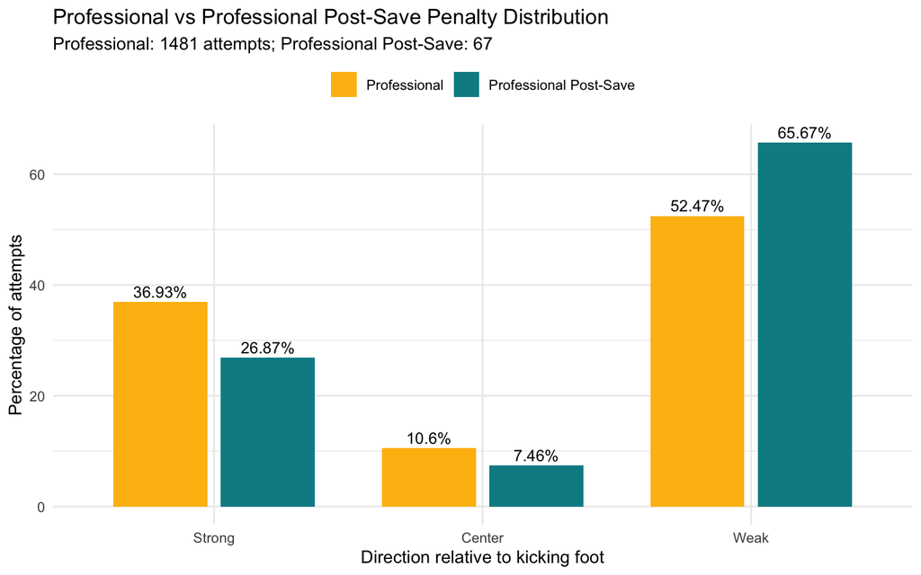

Figure 2: Professional penalty-direction distributions overall and following a saved attempt.

# Conclusion

The NCAA and professional samples produced nearly identical side distributions, suggesting that penalties may follow a stable general pattern of approximately 37% strong, 10% center, and 53% weak. Goalkeepers should be aware of this population-level tendency and consider how it could inform their penalty-saving preparation.

The post-save data also suggest that players may shift away from the strong side and toward the weak side after having a penalty saved. This result is not conclusive, and more verified sequences must be collected. If the pattern is confirmed in a larger sample, a previous save could become a useful signal when evaluating a player’s likely direction.

Penalty saving is often regarded as an art, and data cannot completely, or even mostly, predetermine where a player will shoot. A goalkeeper must still consider individual tendencies, match context, run-up cues, and intuition. However, this does not mean penalty decisions are entirely unpredictable or that historical data cannot provide useful information. Overall, the results indicate that penalty kicks contain consistent and potentially actionable patterns. Statistical analysis should therefore supplement, rather than replace, the goalkeeper’s preparation and judgment.

## Data

- **Professional sample:** The professional analysis used StatsBomb Open Data containing 1,557 penalty attempts from elite club and international competitions. After removing attempts without a valid date, kicking foot, or placement coordinate, 1,481 penalties remained. [StatsBomb Open Data](https://github.com/statsbomb/open-data)
- **NCAA sample:** The collegiate analysis used 419 penalties manually coded from NCAA tournament and conference shootout videos. Six attempts from the shootouts analyzed were not included in the videos, leaving 413 valid penalties.
- **Post-save sample:** The initial data contained 93 observed sequences following a saved penalty. After manually checking for intervening penalties, 67 sequences were verified or corrected. Twenty-four women’s sequences could not be independently verified, and two unreliable cases were removed.